# Program1: Lyrics Analysis across Time with R

### *Ziyang Zhang(zz2683)*

### Looking for song genre trends across time

When dealing with data, because there is only one song in 1960s, we decide to ignore its effect across time(i.e. Treat this song as an outlier.). According to the histogram, we can easily find that **Rock** is always the most popular genre across time because of the large area of pink.

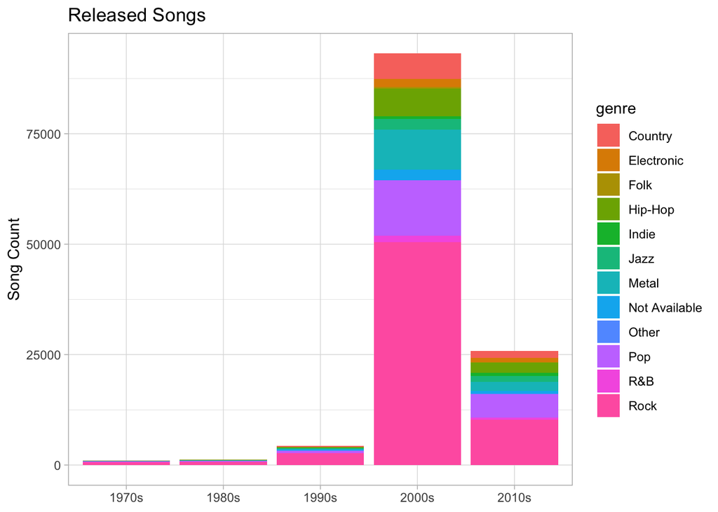

### Length of songs by year

Let’s find the top 10 years with the most number of words

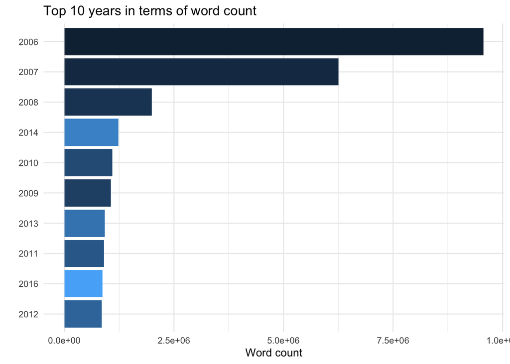

Let’s do a simple evaluation of the most frequently used word in the full set of lyrics from 1968 to 2016.

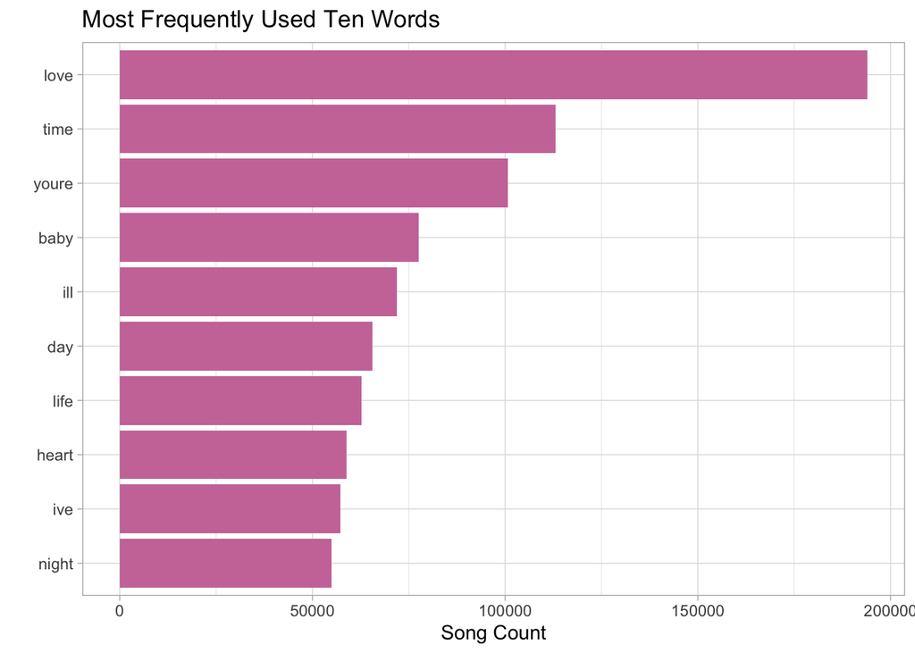

As in most popular music, *love* seems to be a common topic.

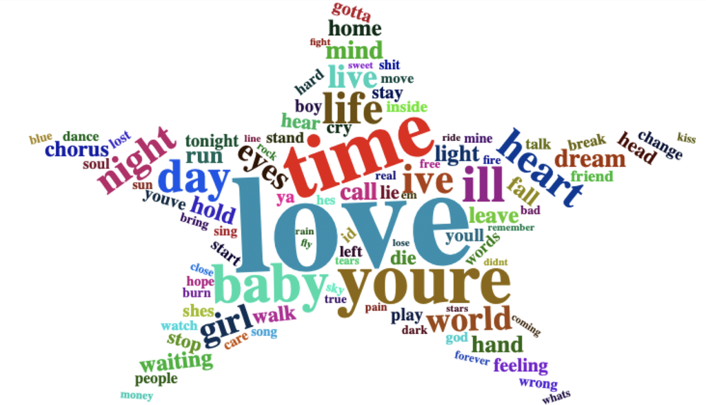

Here is the wordcloud

### Popular Words in Different Genre.

So far we’ve just viewed the top words among all songs from 1968 to 2016. What happened if we break them up by different genre? Are some words more prevalent in songs in *Rock* verse in *Metal*?

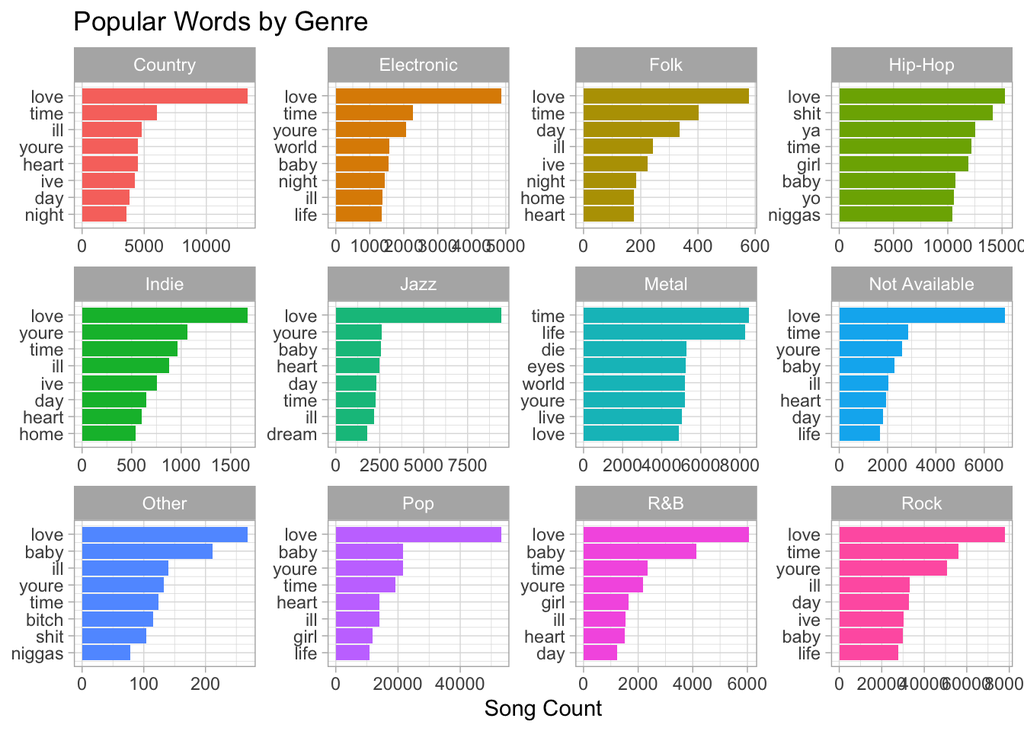

### Timeless Word

Some word in music are considered to be *timeless*. Timeless words perserver over time. They have passed, or have the power to pass, the test of time. They will still be enjoyed by a large number of audience. If we break down the timeline into decades, these word will roll to the top.

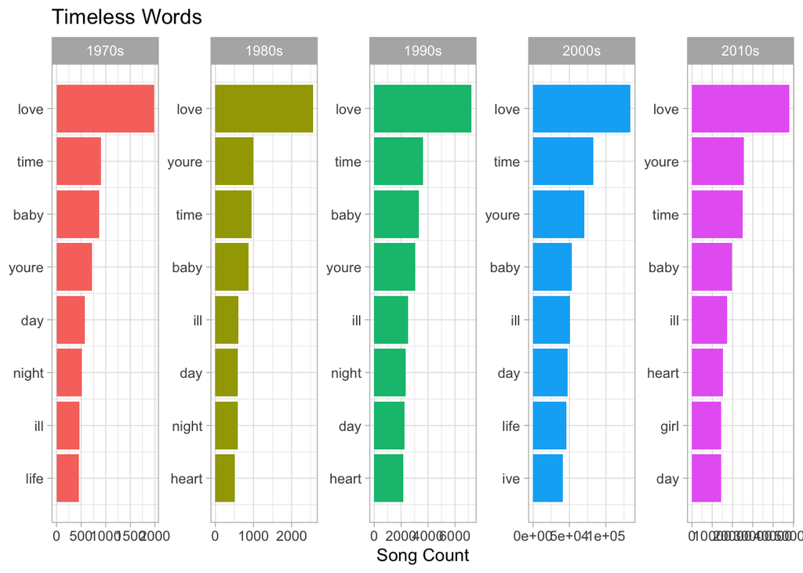

Clearly **love**, **time**, **youre**, **baby** are timeless.

### Sentiment changes across time.

There are three sentiment dictionaries. The AFINN lexicon measures sentiment with a numeric score betwen -5 and 5. But the other two lexicons could only categorize words in a binary way: positive or negative. The difference between NRC and Bing is NRC has eight categories while Bing only have 2.

We want to evaluate the sentiment in a numeric way. Thus we choose AFINN lecicon to score every word in lyrics. We want to see the change of emotions from 1968 to 2016.

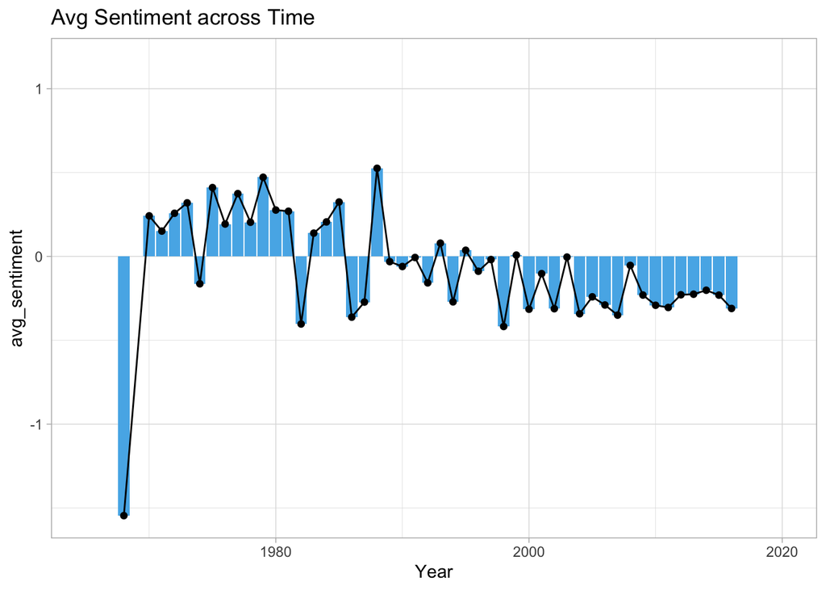

It is a little wierd that in 1968, the average sentiment score is very negative. When we check what was happened in 1968, we find that there is only one song named $Without$ $You$ in 1968, which is a Rock music about broken love. Thus, it is not hard to understand why the emotion in 1968 is extremely negative.

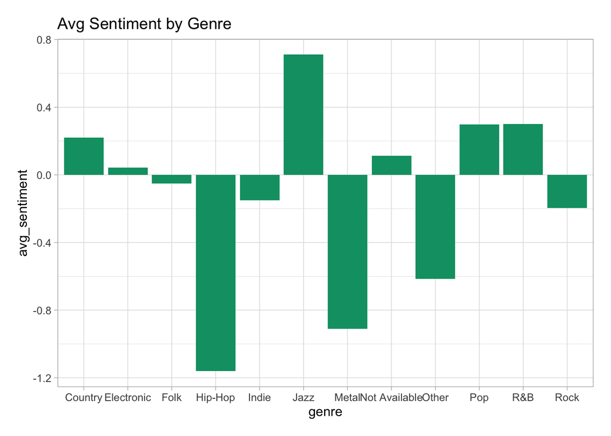

From the above figure, we could find that the metal, Hip-Hop, Rock and Other music have relatively negative emotions.

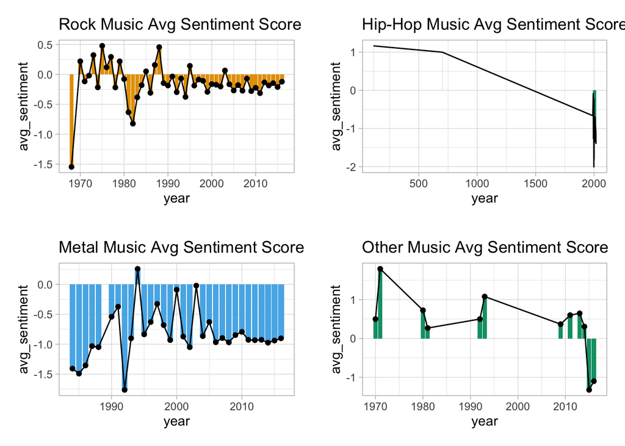